# lab1

Mahmoud Mousa Hamad

1/15/2020

# Task 1

> Print working directory.

```r
getwd()
```

```
## [1] "/cloud/project/lab1"
```

# Task 2

> Obtain first six lines of the data.

```r
ddt = read.csv("Lab1.csv")
head(ddt)
```

```
##   RIVER MILE  SPECIES LENGTH WEIGHT DDT
## 1   FCM    5 CCATFISH   42.5    732  10
## 2   FCM    5 CCATFISH   44.0    795  16
## 3   FCM    5 CCATFISH   41.5    547  23
## 4   FCM    5 CCATFISH   39.0    465  21
## 5   FCM    5 CCATFISH   50.5   1252  50
## 6   FCM    5 CCATFISH   52.0   1255 150
```

# Task 3

## Task 3.1

> What are the qualitative variables in “ddt”?

> ANSWER: RIVER and SPECIES

## Task 3.2

> What are the quantitative variables in “ddt”?

> ANSWER: MILE, LENGTH, WEIGHT, and DDT.

## Task 3.3

> How many SPECIES are in the ddt data set?

> ANSWER: 3

## Task 3.4

> Subset the ddt data set so that we see only the observations with SPECIES, LMBASS and WEIGHT bigger than 800gms.

```r
ddt[ddt$SPECIES %in% c("LMBASS") & ddt$WEIGHT > 800, ]
```

```
##     RIVER MILE SPECIES LENGTH WEIGHT DDT
## 141   TRM  345  LMBASS     30    856 2.2
## 144   TRM  345  LMBASS     36   1433 1.9
```

## Task 3.5

> Subset the ddt data set so that we see only those observations where the RIVER is SCM and DDT bigger than 4.0.

```r
ddt[ddt$RIVER %in% "SCM" & ddt$DDT > 4.0, ]
```

```
##    RIVER MILE  SPECIES LENGTH WEIGHT DDT
## 16   SCM    1 CCATFISH     45    984 9.1
## 17   SCM    1 CCATFISH     43    965 7.8
## 18   SCM    1 CCATFISH     45   1084 4.1
```

## Task 3: Clicker Questions Sub-Sections

### Q1

> Find the mean length of fish in the ddt data frame

```r
mean(ddt$LENGTH)
```

```
## [1] 42.8125
```

### Q2

> What is the standard deviation of the weight of fish in the ddt data frame?

```r
sd(ddt$WEIGHT)
```

```
## [1] 376.5461
```

### Q3

> Is this the plot of LENGTH vs WEIGHT from the ddt data frame?

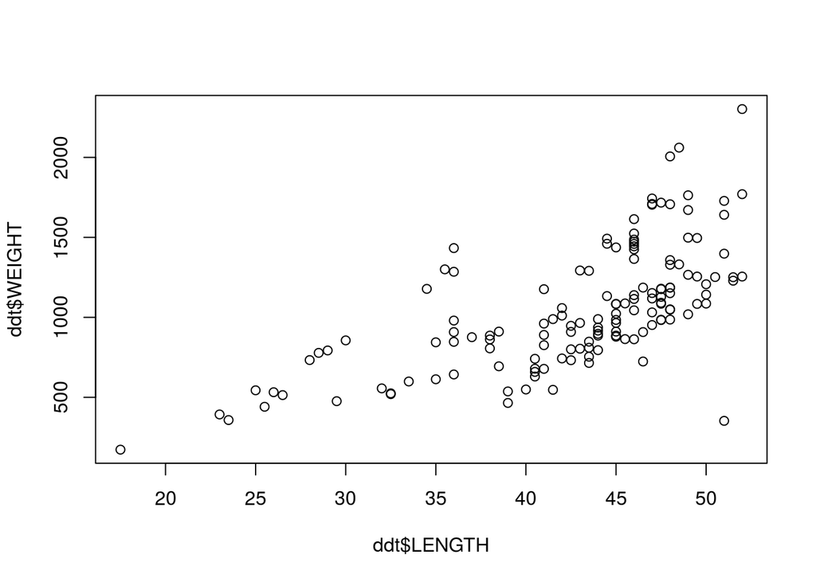

```r
plot(ddt$LENGTH, ddt$WEIGHT)
```

> ANSWER: YES

### Q4

> If v=1:20 what is the last value of v/20?

```r
v = 1:20
(v/20)[20]
```

```
## [1] 1
```

# Task 4

## Task 4.1

> Make a table of the rivers.

```r
table(ddt$RIVER)
```

```
##
## FCM LCM SCM TRM
##   6   6   6 126
```

## Task 4.2

> Make a color coded barplot of the rivers.

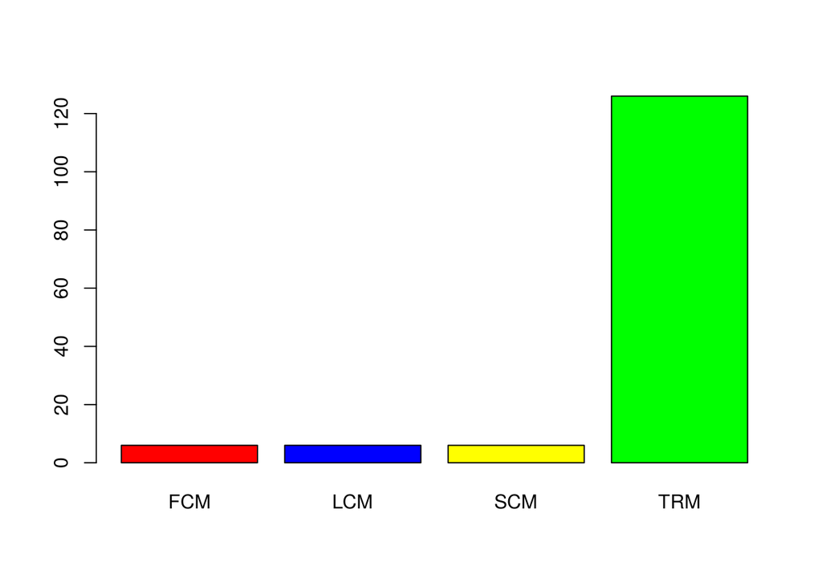

```r
barplot(table(ddt$RIVER), col = c("red", "blue", "yellow", "green"))
```

## Task 4.3

> Make a table of the rivers crossed with the species of fish.

```r
table(ddt$RIVER, ddt$SPECIES)
```

```
##
##       CCATFISH LMBASS SMBUFFALO
##   FCM        6      0         0
##   LCM        6      0         0
##   SCM        6      0         0
##   TRM       78     12        36
```

## Task 4.4

> Make a barplot of the rivers crossed with the species of fish.

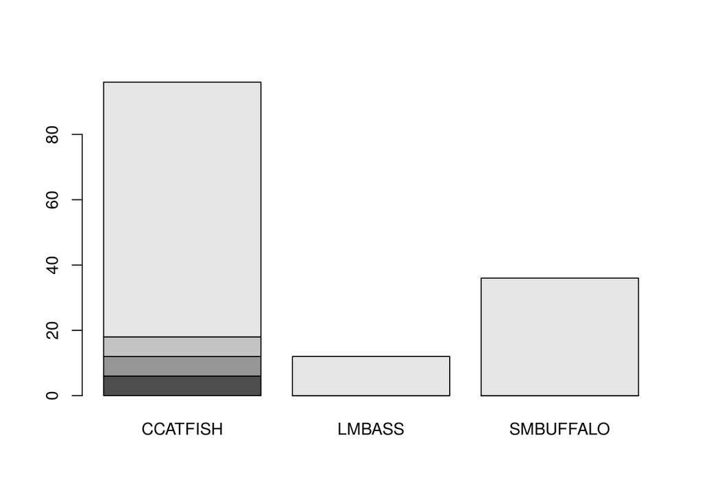

```r
barplot(table(ddt$RIVER, ddt$SPECIES))
```

# Task 5

> Make a pie chart of Fish SPECIES

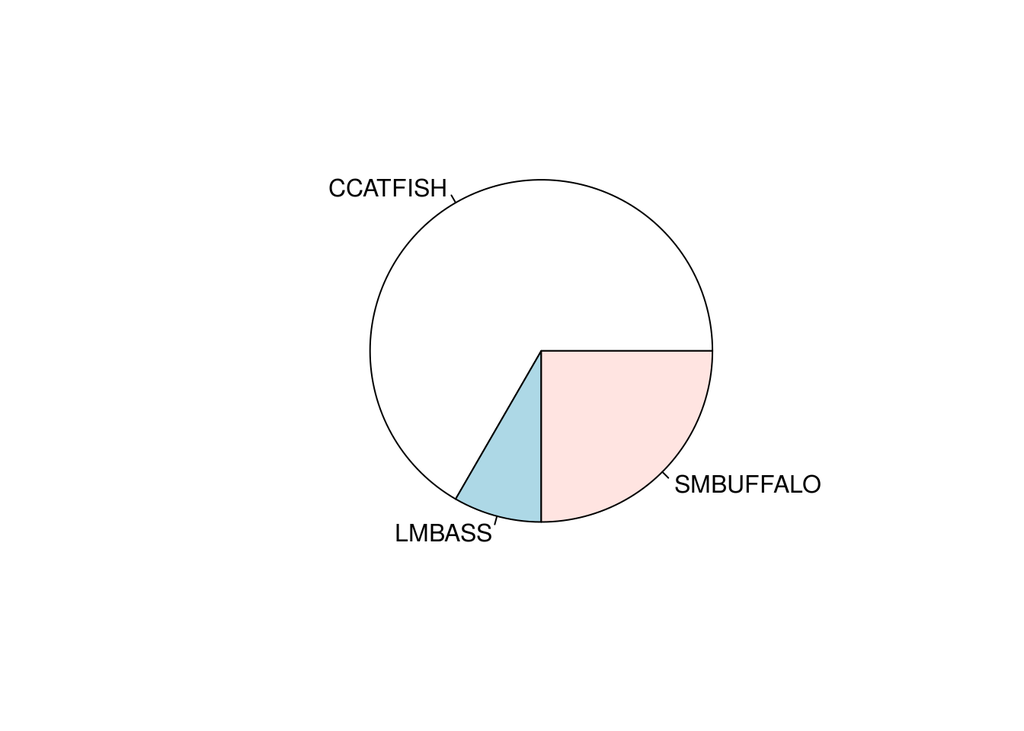

```r
pie(table(ddt$SPECIES))
```

> Make a pie chart of RIVERS

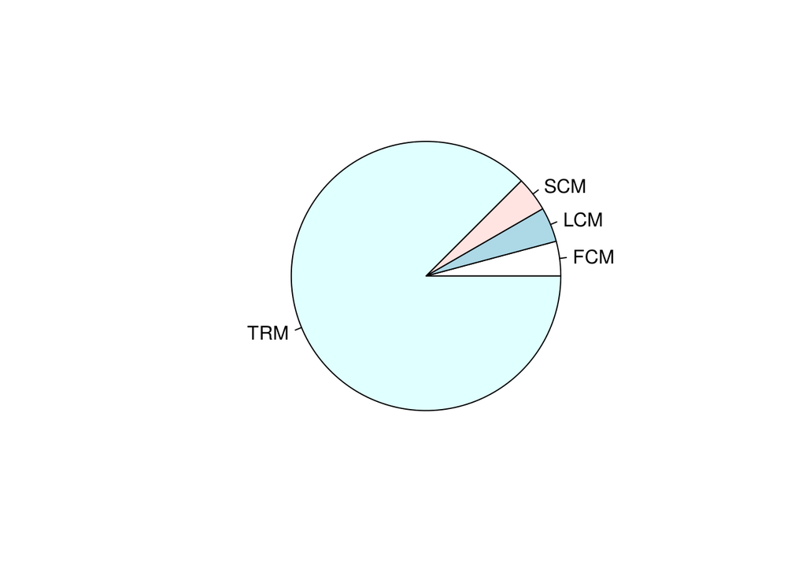

```r
pie(table(ddt$RIVER))
```

# Task 6

> Make a boxplot of the variable DDT

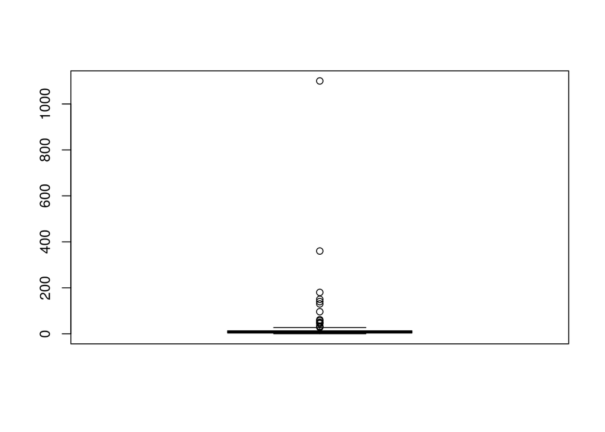

```r
boxplot(ddt$DDT)
```

> Make a boxplot of the variable WEIGHT

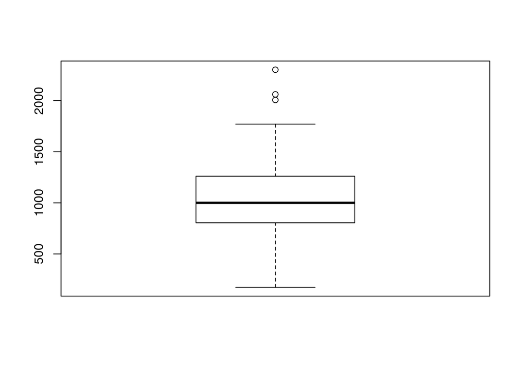

```r
boxplot(ddt$WEIGHT)
```

> Make a boxplot of the variable LENGTH

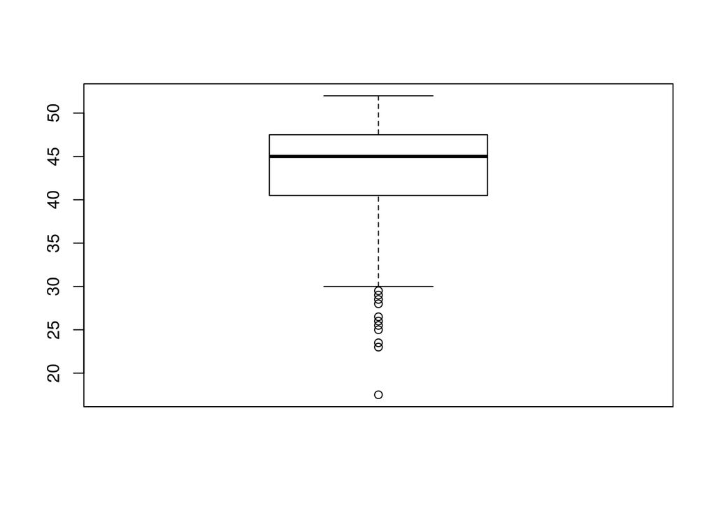

```r
boxplot(ddt$LENGTH)
```

# Task 7

> Make a coplot of LENGTH Vs WEIGHT given RIVER

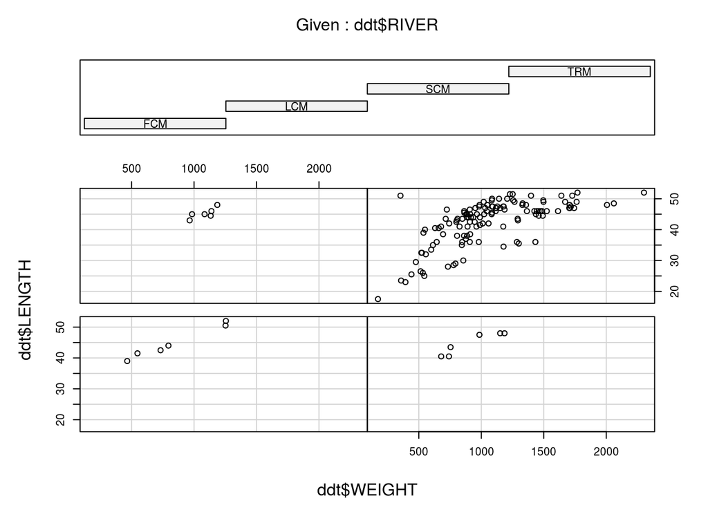

```r
coplot(ddt$LENGTH ~ ddt$WEIGHT | ddt$RIVER)
```

> Make a coplot of DDT Vs WEIGHT given SPECIES

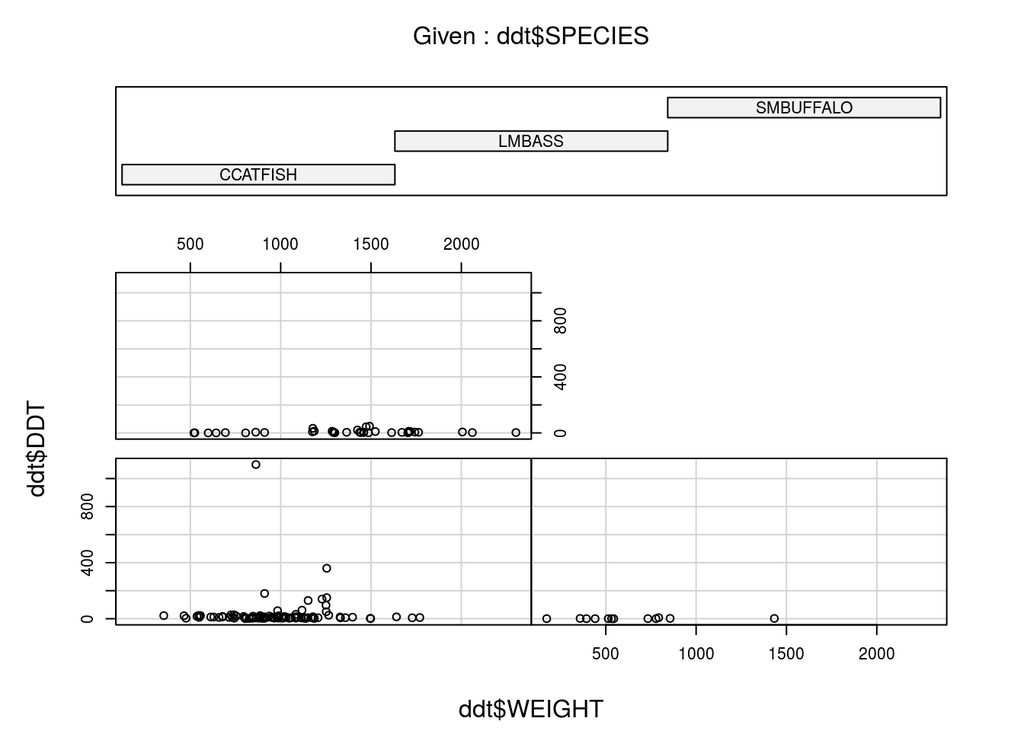

```r
coplot(ddt$DDT ~ ddt$WEIGHT | ddt$SPECIES)
```

# Task 8

> Boxplot

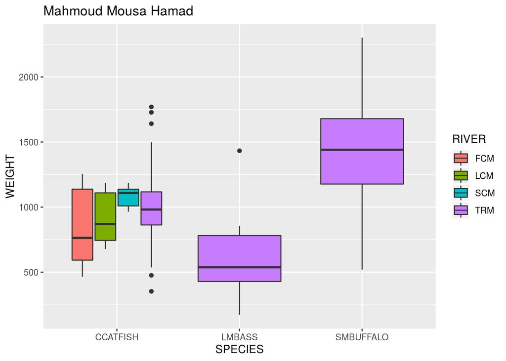

```r
ggplot2::ggplot(ddt, ggplot2::aes(x = SPECIES, y = WEIGHT, z = RIVER, fill = RIVER)) +      ggplot2::geom_boxplot() +
ggplot2::ggtitle("Mahmoud Mousa Hamad")
```

> Violin plot

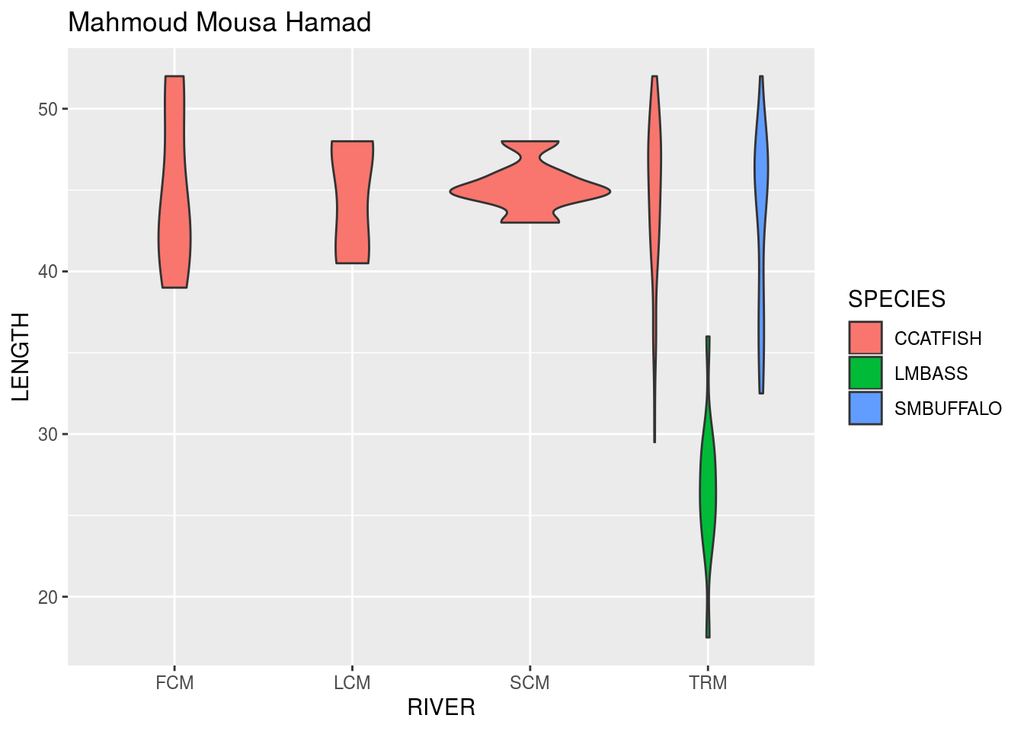

```r
library(ggplot2)
ggplot(ddt, aes(x = RIVER, y = LENGTH, z = SPECIES, fill = SPECIES)) +
geom_violin()  +
ggtitle("Mahmoud Mousa Hamad")
```

> Scatter plot

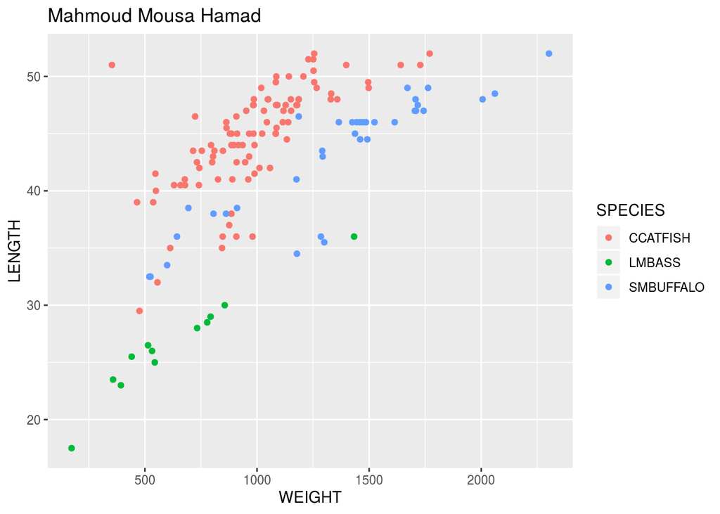

```r
library(ggplot2)
ggplot(ddt, aes(x = WEIGHT, y = LENGTH, z = SPECIES, fill = SPECIES, color = SPECIES)) +
geom_point()  +
ggtitle("Mahmoud Mousa Hamad")
```